# Regularized Regression

Ryan Yee

## Introduction

This lab will take a look at (1) regularized regression models

Note that regularization – ridge and lasso, etc. – can be used for **both linear and logistic regression**.

### Loading Packages

We load `tidymodels` for modeling functions, `ISLR` and `ISLR2` for data sets, and the `tidyverse`. We also need to load the `glmnet` package, since we’ll use it as the engine for the regularized regressions.

```r
library(tidymodels)
library(ISLR)
library(ISLR2)
library(tidyverse)
library(glmnet)
library(modeldata)
library(ggthemes)
library(janitor) # for naming conventions
library(naniar) # to assess missing data patterns
library(corrplot) # for a correlation plot
library(themis) # for upsampling
tidymodels_prefer()
```

### Data

We’ll be working with two data sets for this lab, one to illustrate a regression problem and one to illustrate a classification problem. Let’s take a look at each one.

#### Regression: Baseball salaries

For regression, we’ll use the `Hitters` data set; `Hitters` is included in the `ISLR` package, so we can use it once we’ve loaded that package. Our goal to predict baseball players’ `Salary` based on several different characteristics which are included in the data set, like their number of times at bat, number of hits, division, etc.

We’ll turn the data set into a tibble (the `tidyverse` version of a data frame) and use `head()` to view the first few rows:

```r
hitters <- as_tibble(Hitters)
head(hitters)
```

```
## # A tibble: 6 × 20
##   AtBat  Hits HmRun  Runs   RBI Walks Years CAtBat CHits CHmRun CRuns  CRBI
##   <int> <int> <int> <int> <int> <int> <int>  <int> <int>  <int> <int> <int>
## 1   293    66     1    30    29    14     1    293    66      1    30    29
## 2   315    81     7    24    38    39    14   3449   835     69   321   414
## 3   479   130    18    66    72    76     3   1624   457     63   224   266
## 4   496   141    20    65    78    37    11   5628  1575    225   828   838
## 5   321    87    10    39    42    30     2    396   101     12    48    46
## 6   594   169     4    74    51    35    11   4408  1133     19   501   336
## # ℹ 8 more variables: CWalks <int>, League <fct>, Division <fct>,
## #   PutOuts <int>, Assists <int>, Errors <int>, Salary <dbl>, NewLeague <fct>
```

We can do that with `clean_names()`, which by default will make all columns snake case. (Snake case means all words start with lowercase letters and are separated by underscores, which makes them look_like_little_snakes.)

```r
hitters <- hitters %>%
  clean_names()
head(hitters)
```

```
## # A tibble: 6 × 20
##   at_bat  hits hm_run  runs   rbi walks years c_at_bat c_hits c_hm_run c_runs
##    <int> <int>  <int> <int> <int> <int> <int>    <int>  <int>    <int>  <int>
## 1    293    66      1    30    29    14     1      293     66        1     30
## 2    315    81      7    24    38    39    14     3449    835       69    321
## 3    479   130     18    66    72    76     3     1624    457       63    224
## 4    496   141     20    65    78    37    11     5628   1575      225    828
## 5    321    87     10    39    42    30     2      396    101       12     48
## 6    594   169      4    74    51    35    11     4408   1133       19    501
## # ℹ 9 more variables: crbi <int>, c_walks <int>, league <fct>, division <fct>,
## #   put_outs <int>, assists <int>, errors <int>, salary <dbl>, new_league <fct>
```

We start, as normal, by splitting the data into training and testing sets using stratified sampling; we’ll also use *k*-fold cross-validation with $k = 10$ to fold the training set.

```r
set.seed(3435)
hitters_split <- initial_split(hitters, strata = "salary", prop = 0.75)

hitters_train <- training(hitters_split)
hitters_test <- testing(hitters_split)

hitters_fold <- vfold_cv(hitters_train, v = 10)
```

We’ll set up a recipe for the regression problem first.

```r
hitters_recipe <- recipe(salary ~ . , data = hitters_train) %>%
  step_dummy(all_nominal_predictors()) %>%
  step_normalize(all_predictors()) %>%
  step_impute_linear(salary,
                     impute_with = imp_vars(c_hits, c_runs, crbi, c_walks, c_at_bat),
                     skip = TRUE) %>%
  step_pca(hits, hm_run, runs, rbi, walks,
           num_comp = 1, prefix = "first_pc") %>%
  step_pca(years, c_hits, c_runs, crbi, c_walks, c_at_bat,
           num_comp = 1, prefix = "second_pc")

prep(hitters_recipe) %>% bake(new_data = hitters_train)
```

```
## # A tibble: 240 × 11
##    at_bat c_hm_run put_outs assists errors salary league_N division_W
##     <dbl>    <dbl>    <dbl>   <dbl>  <dbl>  <dbl>    <dbl>      <dbl>
##  1 -0.390   -0.684   1.86    -0.465 -0.624   91.5    1.12      -1.07
##  2 -1.26    -0.826  -0.773    0.162 -0.142   70      1.12      -1.07
##  3 -0.537   -0.839  -0.610    1.29   0.179  100     -0.888      0.933
##  4 -1.63    -0.529  -0.317   -0.594 -0.946  135      1.12       0.933
##  5  0.278   -0.801   0.258   -0.594 -0.946  115     -0.888      0.933
##  6  0.234   -0.736  -0.230   -0.702 -0.624  110      1.12       0.933
##  7 -0.728   -0.775   0.551   -0.328 -0.303   90      1.12       0.933
##  8 -0.231    2.20   -1.05    -0.753 -1.27    NA     -0.888     -1.07
##  9 -1.28    -0.788   0.132   -0.544 -0.463   67.5   -0.888     -1.07
## 10 -1.05    -0.425   0.0630  -0.573 -1.11   180     -0.888     -1.07
## # ℹ 230 more rows
## # ℹ 3 more variables: new_league_N <dbl>, first_pc1 <dbl>, second_pc1 <dbl>
```

We normalize all the predictors first, as is generally recommended when conducting PCA, so that they are all on the same scale. We then extract two principal components, one representing all the common information in the first group of five correlated predictors and the second all the information in the second group.

#### Classification: Customer churn

For classification, we’ll use the `mlc_churn` data set, which is part of the `modeldata` package. It contains a simulated data set that is provided along with certain machine learning software for practice predicting customer churn. Customer churn is a specific name for customer attrition, or whether or not customers stop doing business with an entity or organization. It’s generally in a business’ best interest to retain as many customers as possible and minimize churn, so a model that can accurately predict when customers will stop doing business somewhere is very useful.

```r
mlc_churn <- modeldata::mlc_churn %>%
  as_tibble()

mlc_churn %>%
  head()
```

```
## # A tibble: 6 × 20
##   state account_length area_code     international_plan voice_mail_plan
##   <fct>          <int> <fct>         <fct>              <fct>
## 1 KS               128 area_code_415 no                 yes
## 2 OH               107 area_code_415 no                 yes
## 3 NJ               137 area_code_415 no                 no
## 4 OH                84 area_code_408 yes                no
## 5 OK                75 area_code_415 yes                no
## 6 AL               118 area_code_510 yes                no
## # ℹ 15 more variables: number_vmail_messages <int>, total_day_minutes <dbl>,
## #   total_day_calls <int>, total_day_charge <dbl>, total_eve_minutes <dbl>,
## #   total_eve_calls <int>, total_eve_charge <dbl>, total_night_minutes <dbl>,
## #   total_night_calls <int>, total_night_charge <dbl>,
## #   total_intl_minutes <dbl>, total_intl_calls <int>, total_intl_charge <dbl>,
## #   number_customer_service_calls <int>, churn <fct>
```

```r
set.seed(3435)
mlc_churn <- mlc_churn %>%
  select(-c(total_day_charge, total_eve_charge, total_night_charge,
            total_intl_charge))
mlc_split <- initial_split(mlc_churn, strata = "churn", prop = 0.75)

mlc_train <- training(mlc_split)
mlc_test <- testing(mlc_split)

mlc_fold <- vfold_cv(mlc_train, v = 10)
```

Next, let’s set up the recipe for this data!

```r
churn_recipe <- recipe(churn ~ ., data = mlc_train) %>%
    step_dummy(all_nominal_predictors())

prep(churn_recipe) %>% bake(new_data = mlc_train)
```

```
## # A tibble: 3,749 × 66
##    account_length number_vmail_messages total_day_minutes total_day_calls
##             <int>                 <int>             <dbl>           <int>
##  1            128                    25              265.             110
##  2            107                    26              162.             123
##  3             84                     0              299.              71
##  4             75                     0              167.             113
##  5            147                     0              157               79
##  6            117                     0              184.              97
##  7            141                    37              259.              84
##  8            168                     0              129.              96
##  9             95                     0              157.              88
## 10             62                     0              121.              70
## # ℹ 3,739 more rows
## # ℹ 62 more variables: total_eve_minutes <dbl>, total_eve_calls <int>,
## #   total_night_minutes <dbl>, total_night_calls <int>,
## #   total_intl_minutes <dbl>, total_intl_calls <int>,
## #   number_customer_service_calls <int>, churn <fct>, state_AL <dbl>,
## #   state_AR <dbl>, state_AZ <dbl>, state_CA <dbl>, state_CO <dbl>,
## #   state_CT <dbl>, state_DC <dbl>, state_DE <dbl>, state_FL <dbl>, …
```

```r
set.seed(3435)
mlc_churn <- mlc_churn %>%
  mutate(region = forcats::fct_collapse(state,
                                        west = c("CA", "OR", "WA", "ID",
                                                 "MT", "NV", "WY", "UT",
                                                 "CO", "AZ", "NM", "AK",
                                                 "HI"),
                                        midwest = c("ND", "SD", "NE", "KS",
                                                    "MN", "IA", "MO", "WI",
                                                    "IL", "MI", "IN", "OH"),
                                        northeast = c("ME", "VT", "NH", "MA",
                                                      "CT", "RI", "NY", "PA",
                                                      "NJ"),
                                        south = c("TX", "OK", "AR", "LA",
                                                  "KY", "TN", "MS", "AL",
                                                  "WV", "DE", "MD", "VA",
                                                  "NC", "SC", "GA", "FL",
                                                  "DC"))) %>%
  select(-state)
mlc_split <- initial_split(mlc_churn, strata = "churn", prop = 0.75)

mlc_train <- training(mlc_split)
mlc_test <- testing(mlc_split)

mlc_fold <- vfold_cv(mlc_train, v = 10)
```

```r
churn_recipe_demo <- recipe(churn ~ ., data = mlc_train) %>%
  step_dummy(all_nominal_predictors()) %>%
  step_normalize(all_predictors()) %>%
  step_upsample(churn, over_ratio = 0.5, skip = FALSE)

prep(churn_recipe_demo) %>% bake(new_data = mlc_train) %>%
  group_by(churn) %>%
  summarise(count = n())
```

```
## # A tibble: 2 × 2
##   churn count
##   <fct> <int>
## 1 yes    1609
## 2 no     3219
```

```r
churn_recipe <- recipe(churn ~ ., data = mlc_train) %>%
  step_dummy(all_nominal_predictors()) %>%
  step_normalize(all_predictors()) %>%
  step_upsample(churn, over_ratio = 1)
```

## Elastic Net Regression

`parsnip` does not have a dedicated function to create a ridge regression model specification; we need to use **either** `linear_reg()` or `logistic_reg()` and set `mixture = 0` to specify a ridge model. The `mixture` argument specifies the amount of different types of regularization; `mixture = 0` specifies only ridge regularization and `mixture = 1` specifies only lasso regularization. Setting `mixture` to a value between 0 and 1 lets us use both, which results in a mixture of L1 and L2 regularization, or what is often called an “elastic net.”

The nice thing is that by specifying a range of values for `mixture` between 0 and 1, **inclusive**, we can essentially fit both ridge, lasso, **and** a variety of elastic net models at the same time, considering all our values of `penalty` at the same time! That’s what we’ll do here.

When using the `glmnet` engine, we also need to set a penalty to be able to fit the model. This `penalty` argument corresponds to $\lambda$ in the slides and textbook. Generally, we’ll select the optimal value of $\lambda$ by tuning; its value can essentially range between $0$, which is equivalent to traditional linear or logistic regression, and an upper limit of positive infinity.

```r
en_spec_hitters <- linear_reg(mixture = tune(),
                              penalty = tune()) %>%
  set_mode("regression") %>%
  set_engine("glmnet")

en_spec_churn <- logistic_reg(mixture = tune(),
                              penalty = tune()) %>%
  set_mode("classification") %>%
  set_engine("glmnet")
```

```r
en_workflow_churn <- workflow() %>%
  add_recipe(churn_recipe) %>%
  add_model(en_spec_churn)

en_workflow_hitters <- workflow() %>%
  add_recipe(hitters_recipe) %>%
  add_model(en_spec_hitters)
```

```r
en_grid <- grid_regular(penalty(range = c(0, 1),
                                     trans = identity_trans()),
                        mixture(range = c(0, 1)),
                             levels = 10)
```

```r
tune_res_hitters <- tune_grid(
  en_workflow_hitters,
  resamples = hitters_fold,
  grid = en_grid
)

tune_res_churn <- tune_grid(
  en_workflow_churn,
  resamples = mlc_fold,
  grid = en_grid
)

tune_res_hitters
```

```
## # Tuning results
## # 10-fold cross-validation
## # A tibble: 10 × 4
##    splits           id     .metrics           .notes
##    <list>           <chr>  <list>             <list>
##  1 <split [216/24]> Fold01 <tibble [200 × 6]> <tibble [0 × 3]>
##  2 <split [216/24]> Fold02 <tibble [200 × 6]> <tibble [0 × 3]>
##  3 <split [216/24]> Fold03 <tibble [200 × 6]> <tibble [0 × 3]>
##  4 <split [216/24]> Fold04 <tibble [200 × 6]> <tibble [0 × 3]>
##  5 <split [216/24]> Fold05 <tibble [200 × 6]> <tibble [0 × 3]>
##  6 <split [216/24]> Fold06 <tibble [200 × 6]> <tibble [0 × 3]>
##  7 <split [216/24]> Fold07 <tibble [200 × 6]> <tibble [0 × 3]>
##  8 <split [216/24]> Fold08 <tibble [200 × 6]> <tibble [0 × 3]>
##  9 <split [216/24]> Fold09 <tibble [200 × 6]> <tibble [0 × 3]>
## 10 <split [216/24]> Fold10 <tibble [200 × 6]> <tibble [0 × 3]>
```

`autoplot()` creates a great visualization of the information about each metric across each fold for us, first for MLB then for churn:

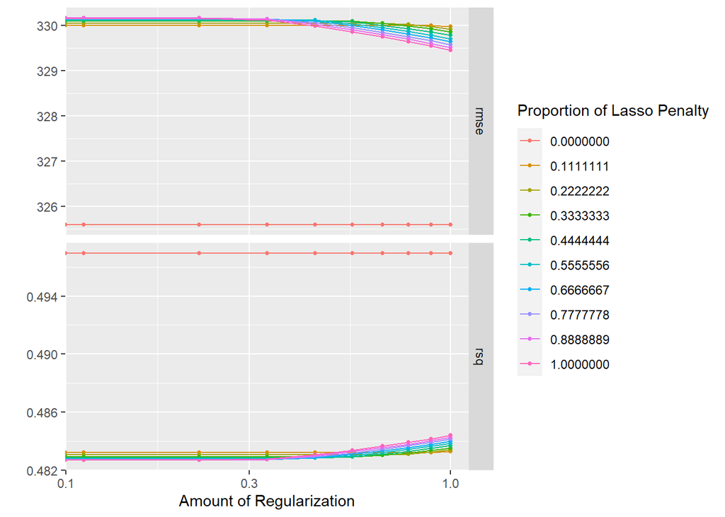

```r
autoplot(tune_res_hitters)
```

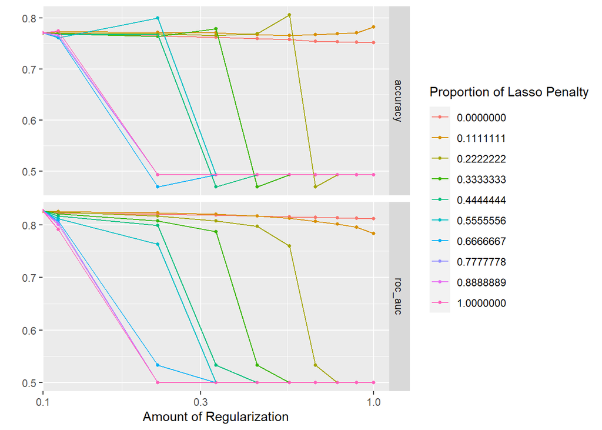

```r
autoplot(tune_res_churn)
```

We’ll demonstrate how to look at/interpret these results for the MLB data, and then suggest that you practice interpreting the customer churn results.

For the MLB data, the scale of the y-axis for both metrics is relatively small, first of all. This indicates that the resulting performance doesn’t really vary drastically across any of the models we’ve fit. The amount of regularization, on the x-axis, is the penalty hyperparameter, which covers the range of values we specified (zero to one), and the values of mixture are represented by the different-colored lines.

Overall, the models with zero percentage of lasso penalty, or the ridge regression models, do better, as indicated by the red line being consistently higher (or lower) than the others. This implies that it yields better performance to avoid reducing predictors all the way down to zero, as can happen in the case of lasso regression. Models with some non-zero proportion of lasso start to do slightly better as the penalty value increases, although still their performance is not near the level of ridge regression.

We can also see the raw metrics that created each of these charts, averaged across all 10 folds, by calling `collect_metrics()` – first for MLB then for churn:

```r
collect_metrics(tune_res_hitters)
```

```
## # A tibble: 200 × 8
##    penalty mixture .metric .estimator    mean     n std_err .config
##      <dbl>   <dbl> <chr>   <chr>        <dbl> <int>   <dbl> <chr>
##  1   0           0 rmse    standard   326.       10 37.1    Preprocessor1_Model…
##  2   0           0 rsq     standard     0.497    10  0.0729 Preprocessor1_Model…
##  3   0.111       0 rmse    standard   326.       10 37.1    Preprocessor1_Model…
##  4   0.111       0 rsq     standard     0.497    10  0.0729 Preprocessor1_Model…
##  5   0.222       0 rmse    standard   326.       10 37.1    Preprocessor1_Model…
##  6   0.222       0 rsq     standard     0.497    10  0.0729 Preprocessor1_Model…
##  7   0.333       0 rmse    standard   326.       10 37.1    Preprocessor1_Model…
##  8   0.333       0 rsq     standard     0.497    10  0.0729 Preprocessor1_Model…
##  9   0.444       0 rmse    standard   326.       10 37.1    Preprocessor1_Model…
## 10   0.444       0 rsq     standard     0.497    10  0.0729 Preprocessor1_Model…
## # ℹ 190 more rows
```

```r
collect_metrics(tune_res_churn)
```

```
## # A tibble: 200 × 8
##    penalty mixture .metric  .estimator  mean     n std_err .config
##      <dbl>   <dbl> <chr>    <chr>      <dbl> <int>   <dbl> <chr>
##  1   0           0 accuracy binary     0.771    10 0.00962 Preprocessor1_Model0…
##  2   0           0 roc_auc  binary     0.826    10 0.0116  Preprocessor1_Model0…
##  3   0.111       0 accuracy binary     0.770    10 0.00842 Preprocessor1_Model0…
##  4   0.111       0 roc_auc  binary     0.822    10 0.0115  Preprocessor1_Model0…
##  5   0.222       0 accuracy binary     0.765    10 0.00773 Preprocessor1_Model0…
##  6   0.222       0 roc_auc  binary     0.820    10 0.0114  Preprocessor1_Model0…
##  7   0.333       0 accuracy binary     0.762    10 0.00793 Preprocessor1_Model0…
##  8   0.333       0 roc_auc  binary     0.818    10 0.0115  Preprocessor1_Model0…
##  9   0.444       0 accuracy binary     0.759    10 0.00763 Preprocessor1_Model0…
## 10   0.444       0 roc_auc  binary     0.816    10 0.0116  Preprocessor1_Model0…
## # ℹ 190 more rows
```